#### Dragos Ailoae

2021-11-29

# Final Exam Prep

**[Prof. Nandi exam topics](https://ciresar.github.io/NYU/Lab_11/nandi_final_exam_topics.pdf)**

## 1. Dummy variables:

Review [lab 9](https://ciresar.github.io/NYU/Lab_9/dummy_dependent_var_intro.html) and [HW3 Solutions](https://ciresar.github.io/NYU/HW3/HW3_solutions.html).

## 2. Instrumental Variables (IV)

Review [lab 6](https://ciresar.github.io/NYU/Lab_6/omitted_variable_bias.html) and [lab 9](https://ciresar.github.io/NYU/Lab_9/instrumental_variables_intro.html).

**[Exam topics:](https://ciresar.github.io/NYU/Lab_11/nandi_final_exam_topics.pdf)**

(iv) Study the formula for IV estimator for estimating parameter vector β.

## 3. Maximum Likelihood Estimation (MLE)

#### Why is Maximum Likelihood Estimation Useful?

Many problems in microeconometrics have data that do not obey classical assumptions

- Integer or dichotomous dependent variables
- Censored or truncated variables
- Stronger distributional assumptions are needed to estimate parameters of the underlying (latent) model from such data
  - Assumption of normality and use of MLE helps

MLE are asymptotically efficient:

- Consistent, asymptotically normal and covariance matrix is “smaller” than cov matrix of any other consistent, asymptotically-normal estimator
- So if we can show that an estimator is an MLE or has the properties of an MLE, it is also showing that this estimator is the most efficient

#### Special case: Maximum Likelihood Estimation of the Linear Model (aka "normal" regression)

CLRM assumptions:

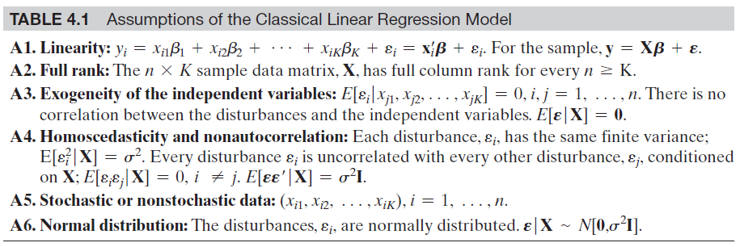

Parameter estimates for $\beta$ can be derived using the following estimation principles:

- Method of least squares - select the best estimator by minimizing the sum of the squared errors for the whole sample
- Method of moments - equate the moments (mean, variance, etc.) implied by a statistical model of the population distribution with the actual moments observed in the sample and solve for the unknown parameter(s) $\theta$
- Method of maximum likelihood (aka "normal regression") - data is drawn from some population distribution (e.g., normal) with unknown parameter(s) $\theta$. Select estimate of $\theta$ so as to maximize the likelihood of seeing the sample actually observed

All lead to the same estimators.

**[Exam topics:](https://ciresar.github.io/NYU/Lab_11/nandi_final_exam_topics.pdf)**

iv) Write the log likelihood function when distribution of observed data is assumed to be normal distribution. Derive the First Order conditions for MLE estimator and estimate the parameters.
vi) 3 Basic techniques of hypothesis testing when Likelihood function is known: (a) Likelihood Ratio Test (b) Wald Test (c) Lagrange Multiplier Test. Read the mathematical formula to use in each case and describe each test very clearly
Numerical problem:
A multiple regression of $y$ on a constant, $x_{1}$, and $x_{2}$ produces the following results: $$ \boldsymbol{X}^{\prime} \boldsymbol{X}=\left[\begin{array}{rrr} 5 & 15 & 25 \\ 15 & 55 & 81 \\ 25 & 81 & 129 \end{array}\right] \quad \text { , } \quad \boldsymbol{X}^{\prime} \boldsymbol{y}=\left[\begin{array}{r} 20 \\ 76 \\ 109 \end{array}\right] $$ $$ RSS = 1.5, ESS = 26.5, n=5, R^{2}=0.95 $$ Furthermore, a regression of $y$ on a constant and $x_{1}$ produces $RSS$ = 2.4. Use the LR, Wald and LM asymptotic tests to test $H_{0}: \beta_2=0$ versus $H_{a}: \beta_2 \neq 0$

## 4. Generalized Least Square Estimator (GLS)

Because of omitted variables, we end up with a situation where the errors are correlated: $$ \mathbf{y}=X \boldsymbol{\beta}+\varepsilon $$ where $\mathbb{E}[\boldsymbol{\varepsilon} \mid X]=\mathbf{0}$ and $\operatorname{var}[\boldsymbol{\varepsilon} \mid X]=\mathbb{E}\left[\varepsilon \varepsilon^{\prime} \mid X\right]=\sigma^2\Omega$.

The consequence is that $\operatorname{var}\left[\hat\beta_{O L S} \mid X\right]\neq \sigma^{2}\left(X^{\prime} X\right)^{-1}$ $$ \begin{aligned} \operatorname{var}\left[\hat\beta_{O L S} \mid X\right] &=\mathbb{E}\left[\left(\hat\beta_{O L S}-\mathbb{E}\left[\hat\beta_{O L S} \mid X\right]\right)\left(\hat\beta_{O L S}-\mathbb{E}\left[\hat\beta_{O L S} \mid X\right]\right)^{\prime} \mid X\right] \\ &=\mathbb{E}\left[\left(X^{\prime} X\right)^{-1} X^{\prime} \varepsilon \varepsilon^{\prime} X\left(X^{\prime} X\right)^{-1} \mid X\right] \\ &=\left(X^{\prime} X\right)^{-1} X^{\prime} \mathbb{E}\left[\varepsilon \varepsilon^{\prime} \mid X\right] X\left(X^{\prime} X\right)^{-1} \\ &=\left(X^{\prime} X\right)^{-1} X^{\prime}\sigma^2\Omega X\left(X^{\prime} X\right)^{-1} \end{aligned} $$

The basic idea behind GLS is to transform the observation matrix $[\mathrm{y} \, \mathrm{X}]$ so that the variance in the transformed model is $\sigma^2 \mathrm{I}$ instead of $\sigma^2\Omega$.

Since $\boldsymbol{\Omega}$ is positive definite, its inverse is positive definite. Thus it is possible to find a nonsingular matrix $\boldsymbol{P}$ such that $$ \mathbf{\Omega}^{-1}=\boldsymbol{P}^{\prime} \boldsymbol{P} $$

NOTE: Matrix P is not a projection matrix!! I'm just following Prof. Nandi's notation.

Typical matrix decompositions used here are:

- the [Cholesky decomposition](https://en.wikipedia.org/wiki/Cholesky_decomposition) $\Omega^{-1} = \boldsymbol{LL'}$ where $\boldsymbol L$ is lower triangular
- or the [eigendecomposition](https://en.wikipedia.org/wiki/Eigendecomposition_of_a_matrix) $\Omega^{-1} = Q \Lambda Q' = Q \Lambda^{-1/2}\Lambda^{-1/2} Q^{\prime}$

**[Exam topics:](https://ciresar.github.io/NYU/Lab_11/nandi_final_exam_topics.pdf)**

v) Learned in Detail all aspects of GENERALIZED LEAST SQUARE estimator]: transformation of data, formula for slope estimate, covariance matrix, etc.